# Precio y Rendimiento Activos

2/14/2022

En esta práctica vamos a estimar los paramétros $\mu, \sigma$ que definen la ecuación de comportamiento de un activo

$$dS=S\mu dt+S\sigma dW$$

Donde $dW=\epsilon\sqrt{dt}$ y $\epsilon$ se comporta como una normal con media cero y varianza 1.

```r
library(quantmod)
library(PerformanceAnalytics)
library(tidyverse)
library(moments)
library(lubridate)
```

```r
clave <- c("GFNORTEO.MX")
getSymbols(clave, warnings = FALSE)
```

```
## [1] "GFNORTEO.MX"
```

```r
lista <- lapply(clave, function(x) Cl(get(x)))
precio <- (do.call(merge,lista))
```

El objeto precio contiene el precio de el activo que voy a trabajar. Graficamente la evolución de este precio se ve así

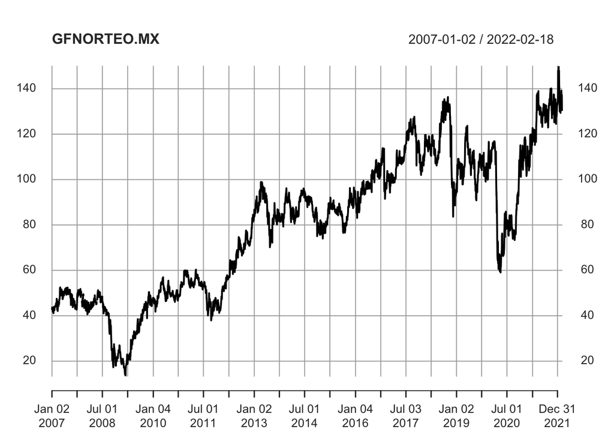

```r
plot(precio, main=clave)
```

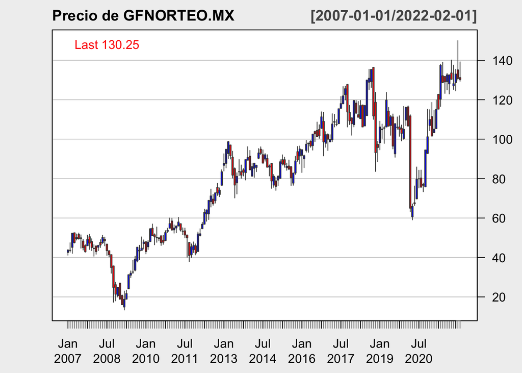

```r
chartSeries(to.monthly(precio), theme="white", up.col="blue", dn.col="red",
            name = paste("Precio de", clave))
```

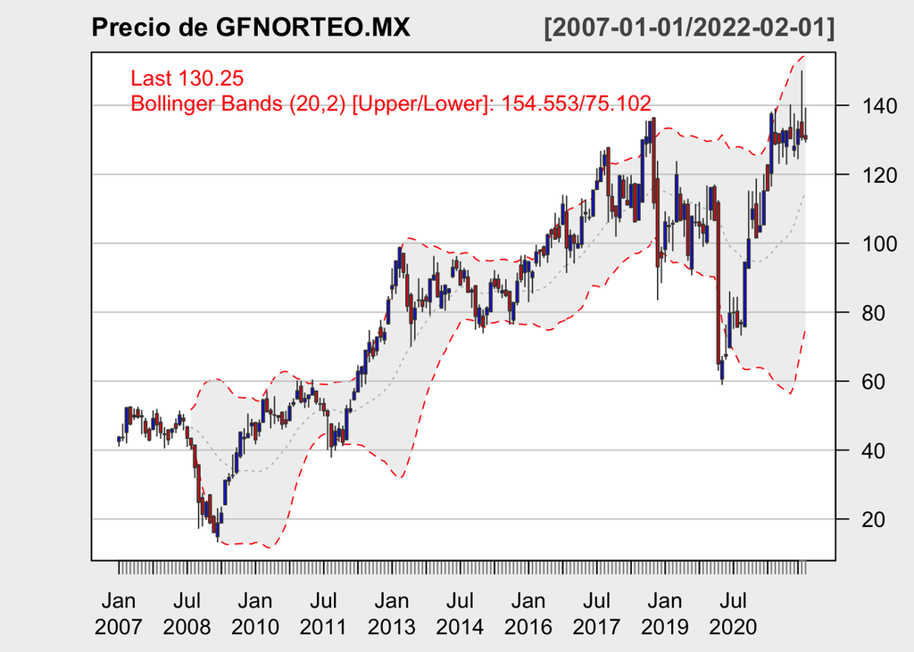

```r
addBBands()
```

Entonces ahora pues vayamos al punto, obtengamos el rendimiento del precio

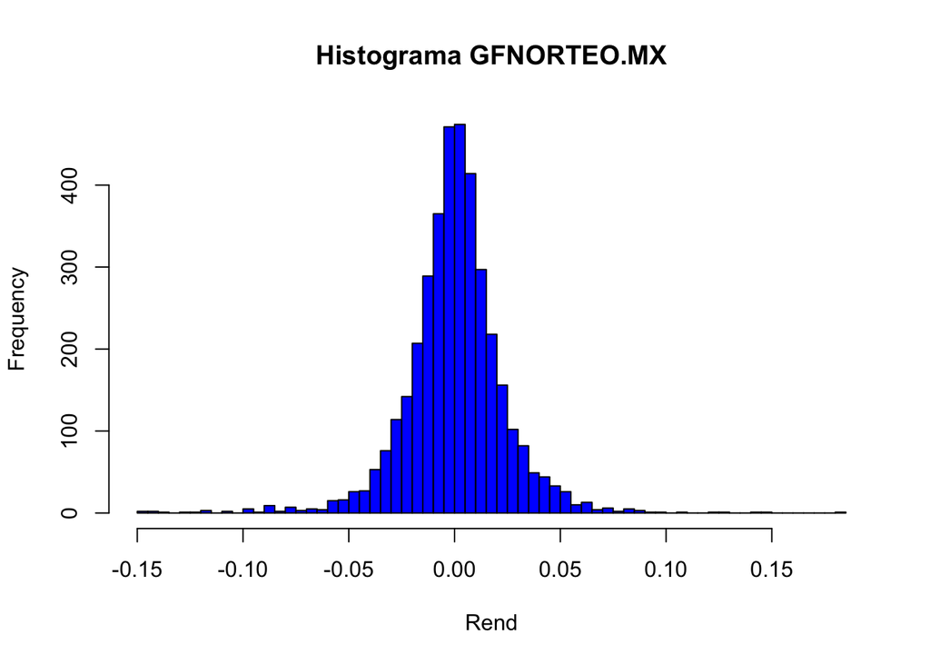

```r
Rend <- na.omit(diff(log(na.omit(precio))))
hist(Rend, n=100, main = paste("Histograma", clave), col="blue")
```

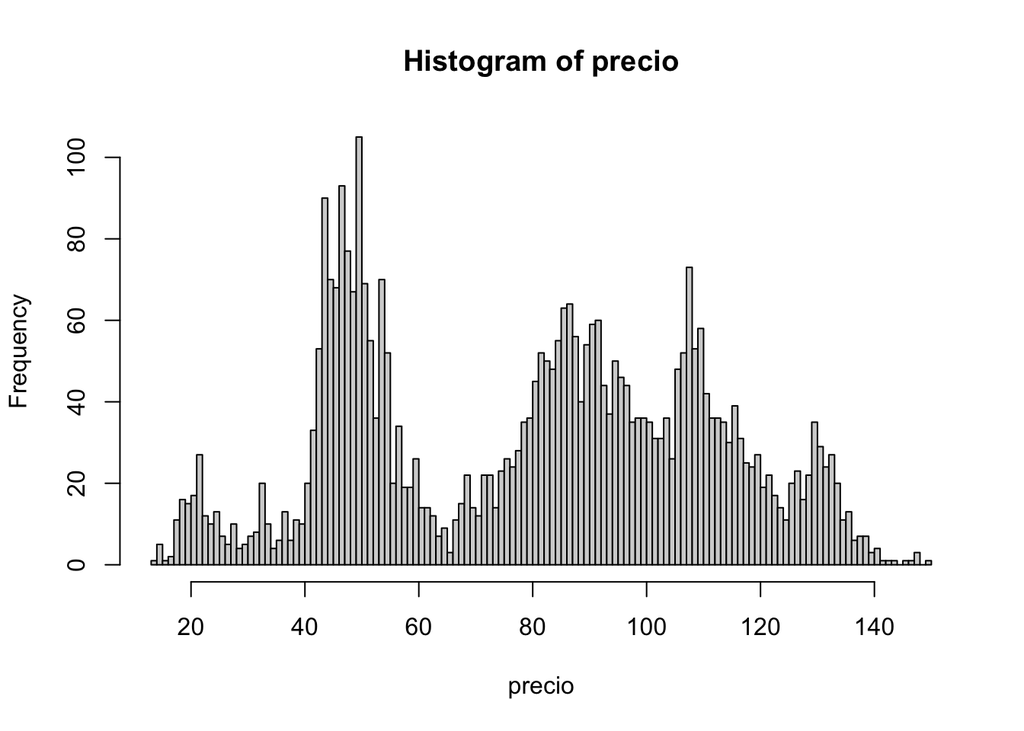

```r
hist(precio, n=100)
```

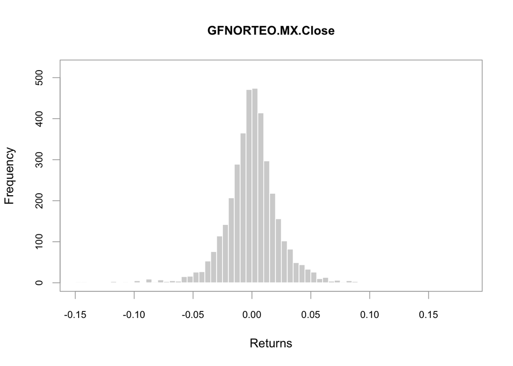

```r
chart.Histogram(Rend)
```

```r
names(precio) <- c("precio")
names(Rend) <- c("rendimiento")
Anio <- year(Rend)

Est_Prin <- Rend %>%
  as_tibble() %>%
  mutate(year=Anio) %>%
  group_by(year) %>%
  summarise(RenDiario=mean(rendimiento),
            RenAnual=mean(rendimiento)*252,
            VolDiaria=sd(rendimiento),
            VolAnual=sqrt(var(rendimiento)*252))
```

De todo el periodo

```r
Ren_Diario_Todo <- mean(Rend)
Vol_Diario_Todo <- sd(Rend)
Ren_Diario_Todo
```

```
## [1] 0.0002946788
```

```r
Vol_Diario_Todo
```

```
## [1] 0.02346873
```

Ahora vamos probar la normalidad del rendimiento de formal visual

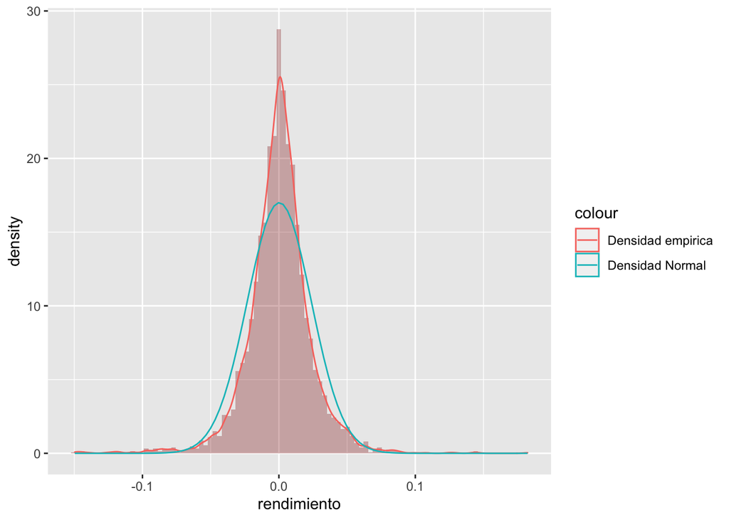

```r
Rend %>%
  as_tibble() %>%
  ggplot(aes(x=rendimiento))+
  geom_histogram(aes(y=..density..), bins = 100, fill="darkred", alpha=0.3)+
  geom_density(aes(x=rendimiento, col="Densidad empirica"))+
  stat_function(fun=dnorm, args = list(mean=Ren_Diario_Todo, sd=Vol_Diario_Todo), aes(col="Densidad Normal"))
```

En términos formales, haremos una prueba de hipótesis.

La prueba de hipótesis para la normalidad que usaremos se llama Jarque-Bera. Esta prueba compara el sesgo y la curtosis de una distribución con la de una normal. Si el sesgo es cero y la curtosis es 3, la distribución es normal

$H_0$ normalidad en la variable

$H_a$ no hay normalidad en la variable

```r
jarque.test(as.numeric(Rend))
```

```
##
##  Jarque-Bera Normality Test
##
## data:  as.numeric(Rend)
## JB = 6224.5, p-value < 2.2e-16
## alternative hypothesis: greater
```

Si p-value es menor a 0.01 podemos rechazar Ho con un 99% de certeza que no estamos cometiendo un error. Entonces mi conclusión es que debo rechazar Ho, por lo tanto rechazo las posibilidades de que sea Normal.

```r
kurtosis(Rend)
```

```
## rendimiento
##    9.249088
```

```r
skewness(Rend)
```

```
## rendimiento
##  -0.2799771
```

Prueba formal sobre el rendimiento cero.

Efectuaremos una prueba formal para saber si en realidad la media del rendimiento es estadisticamente igual a cero o no.

Ho: La media de los rendimientos es igual a cero

Ha: La media de los rendimientos es diferente de cero

```r
t.test(as.numeric(Rend))
```

```
##
##  One Sample t-test
##
## data:  as.numeric(Rend)
## t = 0.77351, df = 3794, p-value = 0.4393
## alternative hypothesis: true mean is not equal to 0
## 95 percent confidence interval:
##  -0.0004522347  0.0010415922
## sample estimates:
##    mean of x
## 0.0002946788
```

Con el valor obtenido del p-value NO podemos rechazar Ho. Entonces la media de los rendimientos es estadisticamente igual a cero.

Prueba alternativa para saber si el rendimiento es mayor a cero

H0: Rendimiento promedio diario es mayor o igual a cero

Ha: Rendimiento promedio diario es menor a cero

```r
t.test(as.numeric(Rend), alternative = "less")
```

```
##
##  One Sample t-test
##
## data:  as.numeric(Rend)
## t = 0.77351, df = 3794, p-value = 0.7804
## alternative hypothesis: true mean is less than 0
## 95 percent confidence interval:
##          -Inf 0.0009214614
## sample estimates:
##    mean of x
## 0.0002946788
```

Ahora vamos a simular comportamientos del rendimiento del activo, usando toda la información que ya tenemos. Es decir, daremos valore a la ecuación ds que hemos obtenido

$dS=S\mu dt+S\sigma dW$

Generemos los valores Mu y sigma, usando toda la información disponible que tenemos en términos diarios

```r
mu <- mean(Rend)
sigma <- sd(Rend)
mu
```

```
## [1] 0.0002946788
```

```r
sigma
```

```
## [1] 0.02346873
```

Con estos valores efectuaremos una simulación de la siguiente forma.

$dS=S 2.9467876\times 10^{-4} dt+S 0.0234687 dW$

Esta ecuación representa el cambio del precio por unidad de tiempo diaria.

Nos falta asignar un valor de So, es decir un valor inicial (ultimo conocido)

```r
n <- length(precio)
So <- as.numeric(precio[n])
So
```

```
## [1] 130.25
```

Por lo cual la siguiente ecuación modela el cambio en precio del dia 2022-02-18 al dia correspondiente a el valor de dt

$$dS=(130.25) (2.9467876\times 10^{-4} )dt+(130.25) (0.0234687) dW$$

Por ejemplo si dt=1, entonces este cambio representa el cambio para el día 2022-02-19

Hagamos entonces una simulación para ese cambio

```r
dt <- 1
epsilon <- rnorm(n=1000000, mean=0, sd=1)
dS <- So*mu*dt+So*sigma*sqrt(dt)*epsilon
```

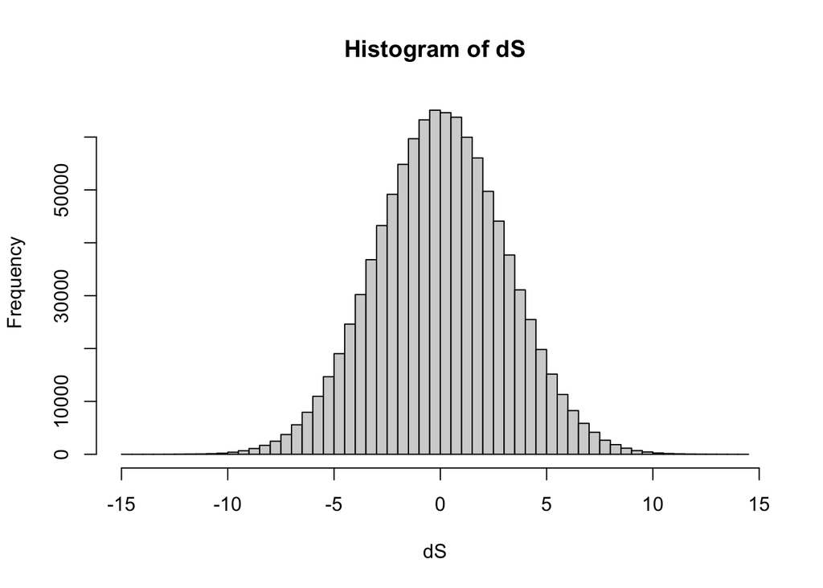

```r
hist(dS, n=50)
```

Entonces si sacamos el promedio de todas las simulaciones contenidas en dS, obtendremos un estimado para el cambio promedio

```r
Esperado_Cambio <- mean(dS)
Esperado_Cambio
```

```
## [1] 0.03635056
```

La varianza del cambio dS

```r
Var_Cambio <- var(dS)
Var_Cambio
```

```
## [1] 9.344363
```

```r
Des_Cambio <- sqrt(Var_Cambio)
Des_Cambio
```

```
## [1] 3.056855
```

Precio Esperado, para el día siguiente es:

```r
PE <- So+Esperado_Cambio
```

Hagamos ahora un intervalo de confianza para el precio, al 95%

```r
z <- qnorm(.025)
PE-z*Des_Cambio
```

```
## [1] 136.2777
```

```r
PE+z*Des_Cambio
```

```
## [1] 124.295
```

Todo esto que hemos hecho, es para un punto especifico del tiempo. Solo para un valor determinado dt. Es decir, estamos viendo nuestro activo, exactamente dt días depués del precio inicial.

Podemos perfeccionar esta simulación usando la ecuación que encontramos sobre el precio

$$S_T=S_0e^{(\mu-.5\sigma^2)dt+\sigma dW}$$

```r
dt <- 1
epsilon <- rnorm(n=10000, mean = 0, sd=1)
S <- So*exp((mu-.5*sigma^2)*dt+sigma*sqrt(dt)*epsilon)
mean(S)
```

```
## [1] 130.3226
```

```r
ne <- 1000 ## simulaciones para cada dia
dias_est <- 252
dt <- seq(1,dias_est, by=1)
St <- matrix(0, nrow=ne, ncol=dias_est)

for (i in 1:dias_est) {
  for (j in 1:ne) {
    epsilon <- rnorm(ne)
    St[,i] <- So*exp((mu-.5*sigma^2)*dt[i]+sigma*sqrt(dt[i])*epsilon)
  }
}
```

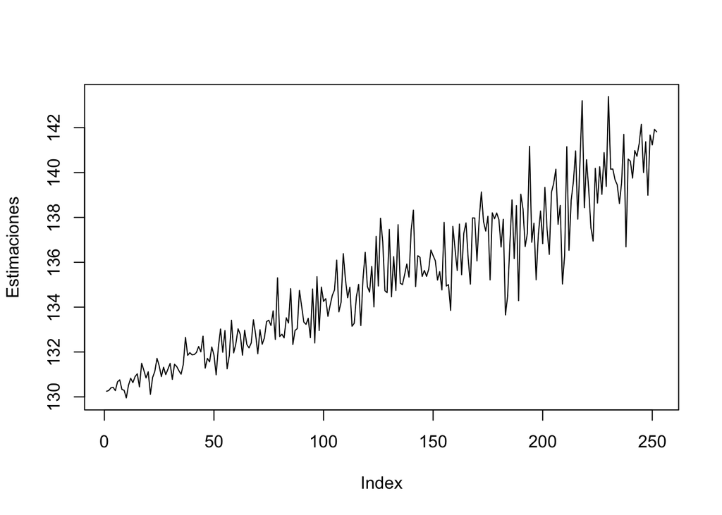

```r
Estimaciones <- colMeans(St)
plot(Estimaciones, type="l")
```